# Relative correlation of microbiome with SparCC

Xin David Zhao

Last edited 23 October 2024

# 1 Introduction

This project was conducted as part of a research initiative on microbiome analysis, addressing challenges related to compositional data.

**Problem:** Classical correlation methods like Pearson and Spearman are inadequate for analyzing microbiome data due to compositionality, leading to spurious correlations.

**Goal:** The aim was to apply SparCC, a specialized tool for microbiome compositional data, to infer accurate correlations between taxa and provide insightful network visualizations.

# 2 Methodology

- Data Collection: Microbiome data was sourced from 16S-seq OTU tables, based on a study from Turnbaugh et al. (2008) involving US twin cohorts, with 557 features across 281 samples.

## 2.1 Code

### 2.1.1 Load libraries

### 2.1.2 Load 16S-seq OTU table

The OTU table based on 16S gene (V2) sequencing was derived from the paper by Turnbaugh et al(Turnbaugh et al. 2008). The microbiome data was collected from the US female twin cohorts with a sample size of 154 individuals in the study. In general, the study by Turnbaugh et al was aimed to evaluate the impact of host genotype and adiposity on compositions and functions of gut microbiota.

Downloaded the OTU table from the [MLRepo](https://knights-lab.github.io/MLRepo/docs/turnbaugh_lean_obese_all.html) website managed by Knights Lab.

The raw OTU table contains 557 features (OTUs) in 281 samples.

Shorten OTU identifiers with keeping only genus and species names, using `stringr` package. And then accumulate counts of OTUs at the species level.

```r
head(raw_otu$X.OTU)
```

```
## [1] "NR_147401.1_Sutterella_massiliensis_strain_Marseille-P2435_16S_ribosomal_RNA__partial_sequence"
## [2] "NR_025930.1_Ruminococcus_bromii_strain_ATCC_27255_16S_ribosomal_RNA_gene__partial_sequence"
## [3] "NR_025230.1_Megasphaera_micronuciformis_strain_AIP_412.00_16S_ribosomal_RNA_gene__partial_sequence"
## [4] "NR_024994.1_Lactobacillus_mucosae_strain_S32_16S_ribosomal_RNA_gene__complete_sequence"
## [5] "NR_024750.1_Coprococcus_catus_strain_VPI-C6-61_16S_ribosomal_RNA_gene__partial_sequence"
## [6] "NR_024684.1_Eubacterium_nitritogenes_strain_JCM_6485_16S_ribosomal_RNA_gene__partial_sequence"
```

```r
# split strings
otu.id <- raw_otu$X.OTU

split_otu.id <- str_split_fixed(otu.id, "_", n=6) %>%
        as.data.frame()

# join genus and species fragments
join_split_otu.id <- split_otu.id %>%
        mutate(taxa = str_c(V3, V4, sep = " "))

taxa <- join_split_otu.id$taxa

# merge taxa to raw otu table
raw_otu_taxa <- cbind(raw_otu, taxa)

# accumulate counts at the species level
otu_count_splevel <- raw_otu_taxa %>%
        gather(key = "sample", value = "count", -c("ID", "X.OTU", "taxa")) %>%
        group_by(sample, taxa) %>%
        summarise(count_sp = sum(count, na.rm = T)) %>%
        arrange(desc(count_sp)) %>%
        ungroup()

otu_count_splevel2 <- otu_count_splevel %>%
        spread(key = "sample", value = count_sp) %>%
        rownames_to_column("otu_id")

otu_count_splevel3 <- otu_count_splevel2

otu_count_splevel4 <- otu_count_splevel3 %>%
  select(-taxa)
```

Export the resulting OTU table in the text format for the subsequent SparCC analysis.

```r
# write out otu data frame in .txt
write.table(otu_count_splevel4,
            file = "otu_sp.txt",
            sep = "\t",
            dec = ".",
            row.names = FALSE,
            na= "NA",
            quote = FALSE)

# read in .txt file
sp_otu <- read.delim("otu_sp.txt")
```

### 2.1.3 Apply SparCC python3 package to OTU data

Use git bash commend line to run SparCC python3 module following the package manual. Below was the commend line to implement SparCC analysis on the microbiome data.

#### 2.1.3.1 install package

python ./SparCC3/SparCC.py -h .

#### 2.1.3.2 correlation calculation

python ./SparCC3/SparCC.py otu_sp.txt -i 5 –cor_file=cor_sparcc_spp.out python ./SparCC3/SparCC.py otu_sp.txt -i 5 –cor_file=cor_pearson_spp.out -a pearson python ./SparCC3/SparCC.py otu_sp.txt -i 5 –cor_file=cor_spearman_spp.out -a spearman

#### 2.1.3.3 pseudo p-value calculation

python ./SparCC3/MakeBootstraps.py otu_sp.txt -n 5 -t permutation_#.txt -p ./

python ./SparCC3/SparCC.py ./permutation_0.txt -i 5 –cor_file=./perm_cor_spp_0.txt python ./SparCC3/SparCC.py ./permutation_1.txt -i 5 –cor_file=./perm_cor_spp_1.txt python ./SparCC3/SparCC.py ./permutation_2.txt -i 5 –cor_file=./perm_cor_spp_2.txt python ./SparCC3/SparCC.py ./permutation_3.txt -i 5 –cor_file=./perm_cor_spp_3.txt python ./SparCC3/SparCC.py ./permutation_4.txt -i 5 –cor_file=./perm_cor_spp_4.txt

python ./SparCC3/PseudoPvals.py cor_sparcc_spp.out ./perm_cor_spp_#.txt 5 -o ./pvals_spp.one_sided.txt -t one_sided python ./SparCC3/PseudoPvals.py cor_sparcc_spp.out ./perm_cor_spp_#.txt 5 -o ./pvals_spp.two_sided.txt -t two_sided

### 2.1.4 Tabulate output from SparCC analysis

```r
# store SparCC coefficients in data frame
full_sparcc <- read.delim("cor_sparcc_spp.out",
                          header = TRUE) %>%
  as.data.frame()

full_sparcc[1:4,1:5] # inspect coefficients based on SparCC
```

|  | otu_id | X1 | X2 | X3 | X4 |
| --- | --- | --- | --- | --- | --- |
| 1 | 1 | 1.00000000 | -0.049105291 | -0.02812794 | -0.018358660 |
| 2 | 2 | -0.04910529 | 1.000000000 | 0.01917322 | -0.006646884 |
| 3 | 3 | -0.02812794 | 0.019173225 | 1.00000000 | 0.019095004 |
| 4 | 4 | -0.01835866 | -0.006646884 | 0.01909500 | 1.000000000 |

To simplify the heatmap plots, identified and filtered out low-abundant taxa that has less than 10 reads in more than 5 samples.

```r
# index low abundant taxa
sp_otu2 <- sp_otu %>%
  column_to_rownames("otu_id")

low_abund_index <- apply(sp_otu2, 1, function(x) sum(x >= 10) >= 5)

full_sparcc2 <- full_sparcc %>%
  column_to_rownames("otu_id")

full_sparcc3 <- full_sparcc2[low_abund_index, low_abund_index] # for generating heat-map
```

Stored the two-sided p values in the data frame. And then filtered out the low abundant taxa from the full table.

```r
# two-sided pval of sparcc coefficients
two.side_pval_sparcc <- read.delim("pvals_spp.two_sided.txt",
                                   header = TRUE) %>%
  as.data.frame()

two.side_pval_sparcc2 <- two.side_pval_sparcc %>%
  column_to_rownames("otu_id")

# filter low abundant taxa
two.side_pval_sparcc3 <- two.side_pval_sparcc2[low_abund_index, low_abund_index]
```

- Model Development and Evaluation: The SparCC model inferred species-level correlations, and p-values were calculated to assess significance. The results were visualized with network and heatmap plots.

# 3 Results

## 3.2 Visualizations

Network plots and heatmaps illustrated the correlation structure, filtered for significance (p < 0.05). Hierarchical edge bundling provided alternative visual perspectives.

### 3.2.1 Visualize SparCC results with heatmap plots

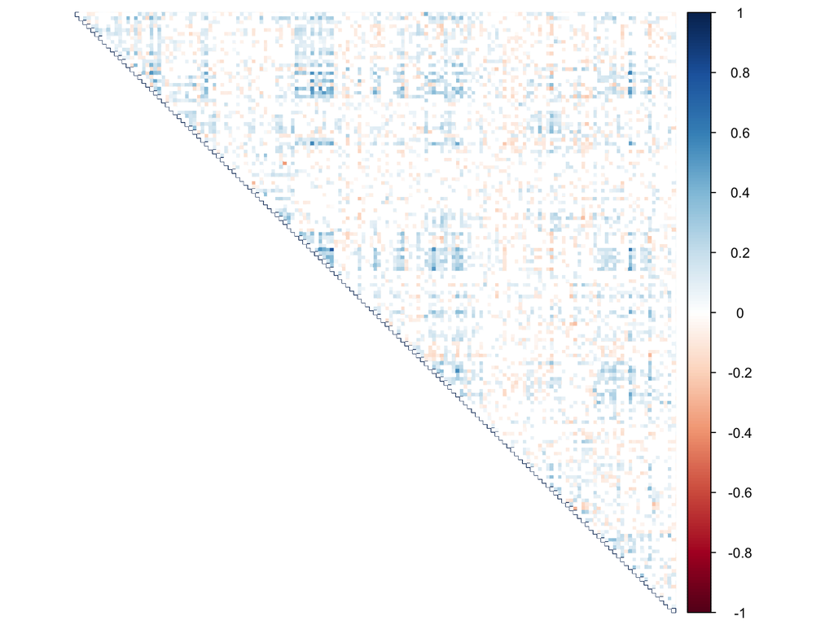

Significant correlations between abundant species based on SparCC analysis. Blue and red color reprents positive and negative correlation, respectively. Empty blocks reprent p-value greater than 0.05.

```r
# prepare correlation matrix
full_sparcc4 <- full_sparcc3 %>%
  rownames_to_column("otu_id") %>%
  mutate(otu_id = paste("X", otu_id, sep = "")) %>%
  column_to_rownames("otu_id") %>%
  as.matrix()

two.side_pval_sparcc4 <- two.side_pval_sparcc3 %>%
  rownames_to_column("otu_id") %>%
  mutate(otu_id = paste("X", otu_id, sep = "")) %>%
  column_to_rownames("otu_id") %>%
  as.matrix()

# heat map based on sparcc coefficients
corrplot::corrplot(full_sparcc4,
                   method = "color",
                   tl.pos = "n",
                   type="upper",
                   p.mat = two.side_pval_sparcc4,
                   sig.level = 0.05,
                   insig = "blank")  # empty cells if pval > 0.05
```

## 3.3 Visualize SparCC outcome with network plots

Applied igraph to visualize network based on SparCC correlation matrix. The [R graph gallery](https://r-graph-gallery.com/250-correlation-network-with-igraph.html) provides detailed R codes and introduction.

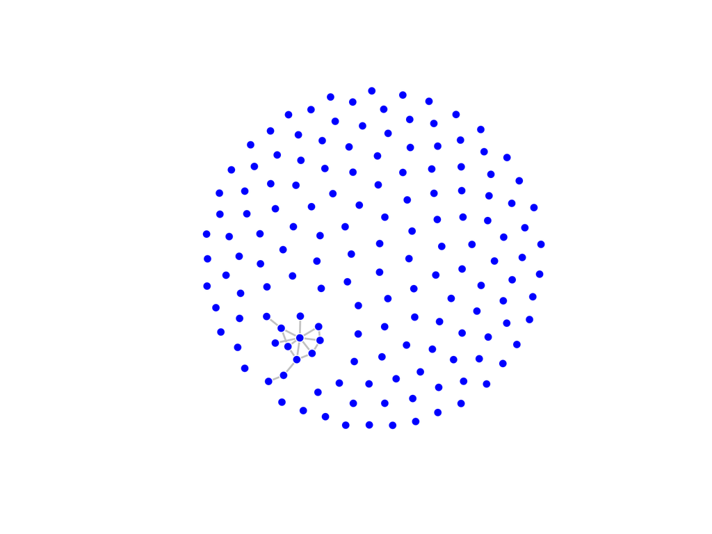

Significant correlation network between species based on SparCC analysis

```r
# correlation coefficient matrix (adjacency matrix) for high-abundant taxa
full_sparcc4_net <- full_sparcc4

# convert coefficients to 1 or 0 according to conditions
cond1 <- two.side_pval_sparcc4 <= 0.05 & full_sparcc4_net >= 0.5
full_sparcc4_net2 <- full_sparcc4_net
full_sparcc4_net2[cond1] <- 1

cond2 <- two.side_pval_sparcc4 > 0.05 | full_sparcc4_net < 0.5
full_sparcc4_net3 <- full_sparcc4_net2
full_sparcc4_net3[cond2] <- 0

# basic network diagram
network_sparcc <- igraph::graph_from_adjacency_matrix(full_sparcc4_net3,
                                                      weighted = T,
                                                      mode = "upper",
                                                      diag=F)

plot(network_sparcc,
     # === vertex
     vertex.color = "blue",
     vertex.frame.color = "white",
     vertex.shape = "circle",
     vertex.size = 5,
     # === vertex label
     vertex.label = NA,
     # === edge
     edge.color = "grey80",
     edge.width = 2)
```

### 3.3.1 Hierarchical edge bundling

Alternatively, use hierarchical edge bundling to illustrate correlation network based on SparCC matrix. The R graph gallery provides [introduction](https://r-graph-gallery.com/309-intro-to-hierarchical-edge-bundling.html) and [advanced](https://r-graph-gallery.com/310-custom-hierarchical-edge-bundling.html) R implementation with `ggraph` package.

Prepare input tables for drawing the hierarchical edge bundling with `igraph` package.

```r
# hierarchical table
taxa_id <- full_sparcc4_net3 %>%
  as.data.frame() %>%
  rownames_to_column("taxa") %>%
  pull(taxa)  # extract 153 species

hierarchy_df <- data.frame(from = rep("origin", 153),  # pseudo origin
                           to = taxa_id)

# vertex table
vertex_df <- data.frame(name = c(taxa_id, unique(hierarchy_df$from)))

# connect table
connect_df <- full_sparcc4_net3 %>%
  as.data.frame() %>%
  rownames_to_column("taxa") %>%
  gather(key = "to", value = "sparcc", -taxa) %>%
  mutate(taxa_is.num = as.numeric(str_sub(taxa, -1)),
         to_is.num = as.numeric(str_sub(to, -1))) %>%
  mutate(keep_upper = to_is.num > taxa_is.num) %>%
  filter(keep_upper == TRUE & sparcc != 0) %>% # upper matrix & coefficient greater than 0.5 and pval < 0.05
  select(from = taxa, to)

# create a graph object
sparcc_hierarchy_plot <- graph_from_data_frame(hierarchy_df, vertices = vertex_df)

# the connection object must refer to the ids of the leaves
from <- match(connect_df$from, vertex_df$name)
to <- match(connect_df$to, vertex_df$name)
```

Draw the hierarchy edge bundling plot with `ggraph` package.

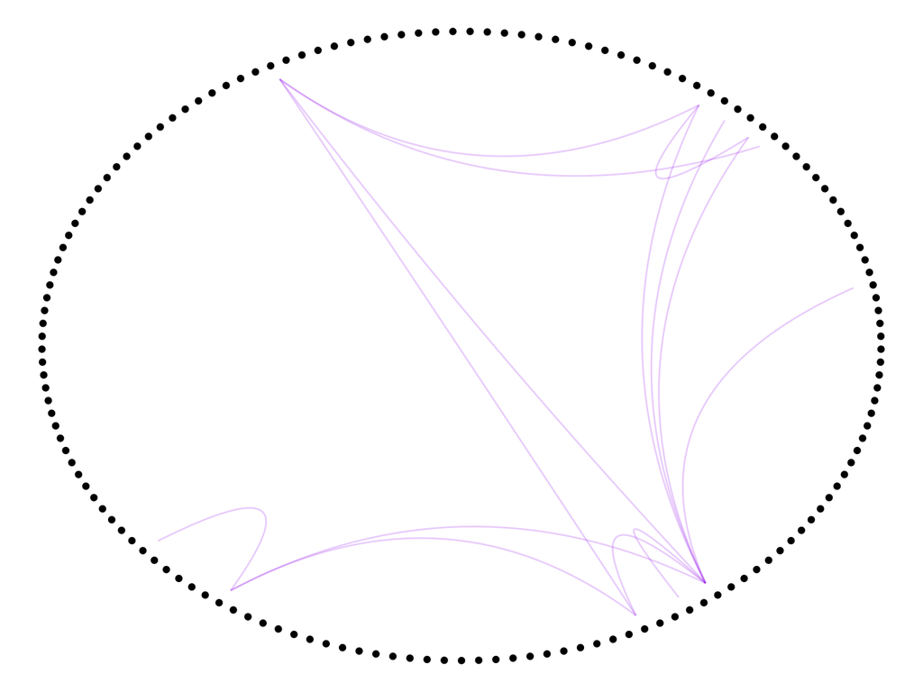

```r
# basic graph
ggraph(sparcc_hierarchy_plot, layout = "dendrogram", circular = TRUE) +
  geom_conn_bundle(data = get_con(from = from, to = to), alpha=0.2, colour = "purple", tension = .5) +
  geom_node_point(aes(filter = leaf, x= x*1.05, y=y*1.05)) +
  theme_void()
```

## 3.5 Reference

Turnbaugh, Peter J., Micah Hamady, Tanya Yatsunenko, Brandi L. Cantarel, Alexis Duncan, Ruth E. Ley, Mitchell L. Sogin, et al. 2008. “A Core Gut Microbiome in Obese and Lean Twins.” *Nature* 457 (7228): 480–84. https://doi.org/10.1038/nature07540.